# Weather events in the U.S.: Health and Economic Consequences

Author: Rodrigo Peres Ferreira Date: April 08, 2016

## Additional Libraries Required

```r
library(plyr)
```

## 1. Data Processing

First, let us unzip and load the original CSV file from NOAA database (The read.csv() function is able to do both).

```r
weather <- read.csv("repdata-data-StormData.csv.bz2")
```

For the purpose of this work, we do not need information about states or date and time, we only need need information about event types, fatalities/injuries and types of damages. We can filter the original data frame to achieve this.

```r
weather_selected <- data.frame(weather$EVTYPE, weather$FATALITIES, weather$INJURIES, weather$PROPDMG, weather$PROPDMGEXP, weather$CROPDMG, weather$CROPDMGEXP)

names(weather_selected) <- c('EVTYPE','FATALITIES','INJURIES', 'PROPDMG', 'PROPDMGEXP', 'CROPDMG', 'CROPDMGEXP')
```

We can also convert the columns “PROPDMG” and “PROPDMGEXP” into one column (“PROPDMG”), since the second column is the magnitude of the value in the first column.

```r
weather_selected$PROPDMG[weather_selected$PROPDMGEXP == 'K'] <-
     weather_selected$PROPDMG[weather_selected$PROPDMGEXP == 'K']*1000

weather_selected$PROPDMG[weather_selected$PROPDMGEXP == 'M'] <-
     weather_selected$PROPDMG[weather_selected$PROPDMGEXP == 'M']*1000000

weather_selected$PROPDMG[weather_selected$PROPDMGEXP == 'B'] <-
     weather_selected$PROPDMG[weather_selected$PROPDMGEXP == 'B']*1000000000

weather_selected <- weather_selected[,-5]
```

We can do the same procedure with the columns “CROPDMG” and “CROPDMGEXP”

```r
weather_selected$CROPDMG[weather_selected$CROPDMGEXP == 'K'] <-
     weather_selected$CROPDMG[weather_selected$CROPDMGEXP == 'K']*1000

weather_selected$CROPDMG[weather_selected$CROPDMGEXP == 'M'] <-
     weather_selected$CROPDMG[weather_selected$CROPDMGEXP == 'M']*1000000

weather_selected$CROPDMG[weather_selected$CROPDMGEXP == 'B'] <-
     weather_selected$CROPDMG[weather_selected$CROPDMGEXP == 'B']*1000000000

weather_selected <- weather_selected[,-6]
```

```r
weather <- weather_selected
weather$EVTYPE <- as.factor(weather$EVTYPE)
```

Now we have a nice 5-variable data frame (weather) we can easily work with for the purposes of this analysis.

## Results

Now we can answer the two main questions of this analysis report.

Let us first aggregate the data, to have the total sum of the number of injuries, fatalities and damages to generate our plots.

```r
weather_aggregation <- ddply(weather,.(EVTYPE),summarize, total_harm=sum(FATALITIES)+sum(INJURIES), total_damage=sum(PROPDMG)+sum(CROPDMG))
```

With this aggregated data, we can answer the questions below.

### Question 1. Across the United States, which types of events are most harmful with respect to population health?

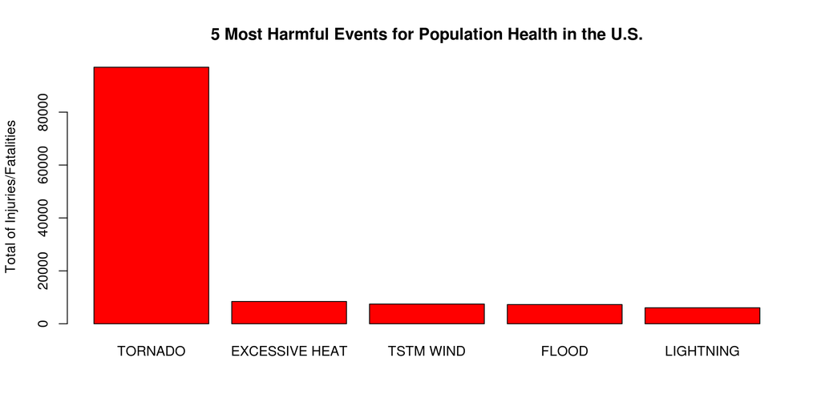

```r
Harms <- weather_aggregation$total_harm
names(Harms) <- weather_aggregation$EVTYPE

Harms <- rev(sort(Harms))

barplot(Harms[1:5], col = "red", main = "5 Most Harmful Events for Population Health in the U.S.", ylab = "Total of Injuries/Fatalities")
```

### Question 2. Across the United States, which types of events have the greatest economic consequences?

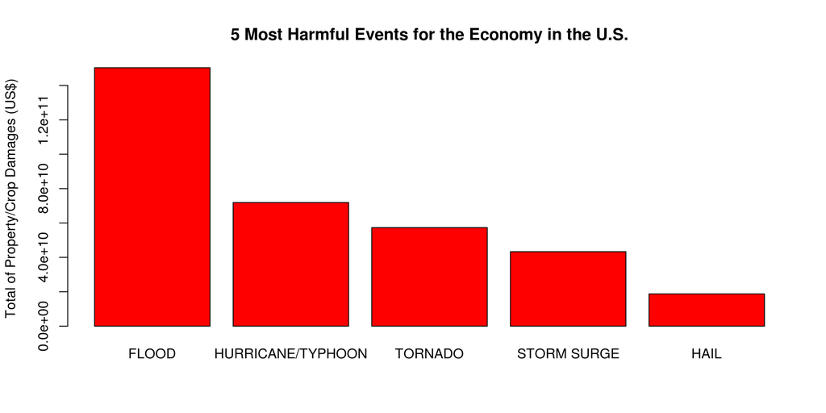

```r
Damages <- weather_aggregation$total_damage
names(Damages) <- weather_aggregation$EVTYPE

Damages <- rev(sort(Damages))

barplot(Damages[1:5], col = "red", main = "5 Most Harmful Events for the Economy in the U.S.", ylab = "Total of Property/Crop Damages (US$)")
```

As we can see from the plot above, the most harmful events for the economy across the U.S. are Floods, Hurricanes, Tornados, Storm Surges (Tides) and Hail.